# Applied Data Science Project 1

Hui Chiang Tay ht2490

28/01/2019

## Introduction

HappyDB is a corpus of 100,000 crowd-sourced happy moments via Amazon’s Mechanical Turk. There is lots of data available with each moment, ranging from the profile of the individual who wrote the moment, to the intensity of happiness felt based on the words used. In this project, we hope to gain a better understanding of happiness through 5 steps. 0. Process the happy moments data set. This is done using the given starter code. 1. Explore the demographics of the individuals surveyed, and clean the data if reqired. 2. Draw possible inferences on the relation between the profile of the individual and the intensity of emotion measured using the VAD model. 3. Predict the category of the happy moment based on the profile of the individual. 4. Examine any differences in words used based on the profile of the individual.

## 1. Data Exploration

We first import the data as data frames. We will be making use of the demographics data, processed moments csv, and the VAD emotional model data. We will combine these 3 data frames for convenience.

We realise that the majority of the columns in our data are character columns. For analysis, it would be more convenient to change these to either factor or numeric columns. We also note that the vast majority of ‘country’ is either USA or India. We group the rest of the countries as ‘Others’. Some of the ‘age’ values are greater than 200, and this is likely due to a mistake in the collection of data and so we will remove these entries. We also remove ‘age’ values less than 10 because again, it is unlikely that the workers surveyed would be of such a young age. Lastly, we remove any ‘NA’ entries for parenthood, gender, marital, or the VAD factors.

```r
main_df$reflection_period <- as.factor(main_df$reflection_period)
main_df$modified <- as.logical(main_df$modified)
main_df$predicted_category <- as.factor(main_df$predicted_category)
main_df$age <- as.numeric(main_df$age)
main_df$country[!(main_df$country %in% c("USA", "IND"))] <- 'Others'
main_df$country <- as.factor(main_df$country)
main_df$gender <- as.factor(main_df$gender)
main_df$marital <- as.factor(main_df$marital)
main_df$parenthood <- as.factor(main_df$parenthood)
main_df <- main_df[!is.na(main_df$parenthood), ]
main_df <- main_df[!is.na(main_df$gender), ]
main_df <- main_df[!is.na(main_df$marital), ]
main_df <- main_df[!is.na(main_df$age), ]
main_df <- main_df[!is.na(main_df$valency), ]
main_df <- main_df[!is.na(main_df$arousal), ]
main_df <- main_df[!is.na(main_df$dominance), ]
main_df <- main_df[(main_df$age<200)&(main_df$age>10), ]
```

We take a look at the 30 most frequently used words, and find that the large majority are words involving family and friends, such as ‘friend’, ‘son’,‘family’ and ‘daughter’. We also note that ‘day’ and ‘time’ are very frequently used, which makes sense considering we use these words to indicate the specific moment in which the happy moment occurred.

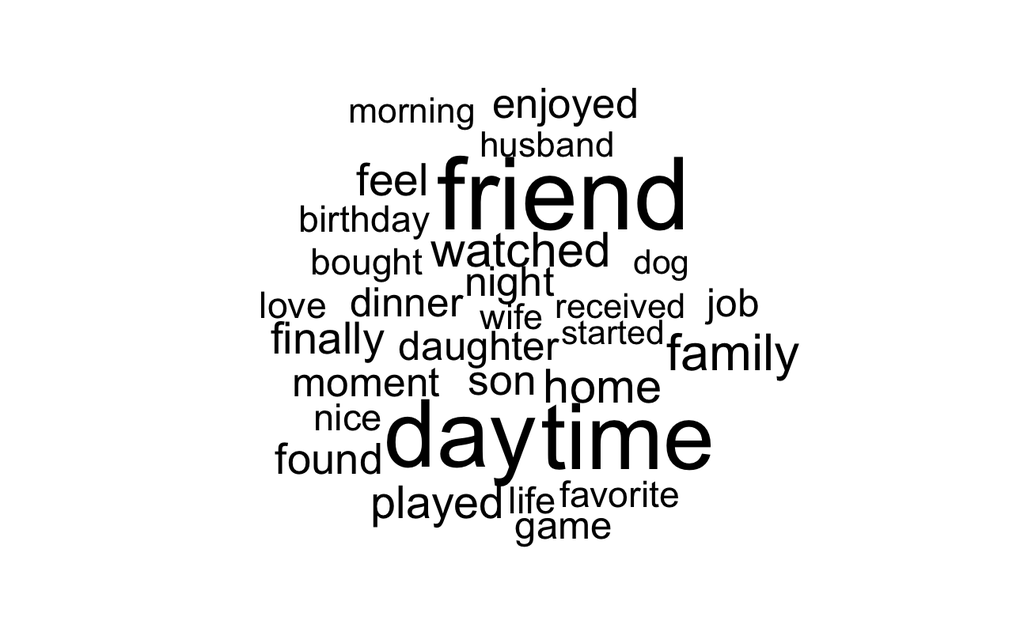

[figure not shown]

```r
counts <- table(main_df$parenthood, main_df$marital)
barplot(counts, main="Marital Status and Parenthood",
  xlab="Marital", col=c("cornflowerblue","palevioletred"),
  legend = rownames(counts))
```

[output not shown]

Now that we have taken a look at some of the features of the data, we would like to investigate a few hypotheses about happiness based on the HappyDB data.

Firstly, we wish to find out if there is any correlation between the profile of each individual, and the intensity of the happiness they express. We theorise that older males exhibit less Dominance and Arousal than younger females. We do not investigate Valency here because all the happy moments will express a higher Valency anyway since happiness is almost equivalent to pleasure.

Secondly, we also wish to find out if we can predict the category of the happy moment given the profile of the individual. For example, perhaps a younger individual would be more likely to express ‘achievement’, while an older individual would be more likely to express ‘affection’ or ‘bonding’.

## 2. Inferring Correlations between Profile and VAD

```r
dominance_lm <- lm(dominance~reflection_period+age+country+gender+marital+parenthood, data=main_df)
summary(dominance_lm)
```

[output not shown]

```r
arousal_lm <- lm(arousal~reflection_period+age+country+gender+marital+parenthood, data=main_df)
summary(arousal_lm)
```

[output not shown]

From this simple analysis, we can see that the profile of an individual does play a role in the way and intensity they express their happiness. However, we also note the limitations of this approach. The factors may seem to be correlated, but we cannot say one directly causes another. Indeed, further study is warranted in investigating how demographics may play a role in the emotional psychology of an individual, in order to explain some of the results here.

## 3. Category Prediction

Now, we attempt to train a random forest to see whether it is possible to classify the happy moment based on the profile of the individual. We chose the random forest because of difficulties with other classifiers. For example, logistic regression assumes a linear relation between the predictor variables, naives Bayes classifiers assumes that the variables are independent of each other which we know to be untrue (parenthood and marital status etc), and k-nearest neighbours requires me to define appropriate distance functions for each variable, which I am unable to.

```r
set.seed(1)
#Subset relevant variables
classify_df <- main_df[,c('reflection_period','predicted_category','age','country','gender','marital','parenthood')]

#Split into train and test data
n = nrow(classify_df)
index = sample(1:n, size = round(0.7*n), replace=FALSE)
train_df = classify_df[index ,]
test_df = classify_df[-index ,]

#Train and test classifier
model <- randomForest(formula=predicted_category~., data=train_df, ntree=500)
pred <- predict(model,test_df)
table(pred, test_df$predicted_category)

#Accuracy
sum(diag(table(pred, test_df$predicted_category)))/nrow(test_df)
```

[output not shown]

We now try to improve our model by undersampling from these 2 categories, that is we remove 50% of the training data that belong to these categories.

```r
#Undersample train data
affection_ind <- which(train_df$predicted_category == "affection")
achievement_ind <- which(train_df$predicted_category == "achievement")
undersample <- min(0.5*length(affection_ind), 0.5*length(achievement_ind))
pick_affection <- sample(affection_ind, undersample)
pick_achievement <- sample(achievement_ind, undersample)
train2_df <- train_df[-c(pick_affection, pick_achievement),]
#Retrain classifier
model <- randomForest(formula=predicted_category~., data=train2_df, ntree=500)
pred <- predict(model,test_df)
table(pred, test_df$predicted_category)
```

```
pred               achievement affection bonding enjoy_the_moment exercise leisure
  achievement             5821      3723    1763             1769      243    1218
  affection               3809      5974    1099             1427      104     754
  bonding                  342       336     208              120        4      61
  enjoy_the_moment          18        13       8               21        0       6
  exercise                   0         0       0                0        0       0
  leisure                   39        30      11               13        4      99
  nature                     0         0       0                0        0       0

pred               nature
  achievement         307
  affection           243
  bonding              13
  enjoy_the_moment      0
  exercise              0
  leisure               0
  nature                0
```

```r
#Accuracy
sum(diag(table(pred, test_df$predicted_category)))/nrow(test_df)
```

```
[1] 0.4095608
```

While we are now able to predict some of the other categories, our accuracy has not changed by much. It seems it is after all quite difficult to predict what moment an individual would express happiness about given his profile.

Lastly, we would like to see if there are any differences between males and females, singles and married people, and young and old (below or above the median, 30), in terms of the words they use to describe their happiness.

## 4. Exploration of Terms

### Males and Females

We first plot the most used terms by males and females. As we saw in the word cloud, the top 3 terms for both groups are ‘day’, ‘time’, and ‘friend’. However, the number of times ‘friend’ is used for males compared to the other terms is much higher. In addition, while both males and females have high usage of family related terms such as ‘wife’, ‘family’ and ‘home’ for males and ‘husband’, ‘son’, ‘family’ and ‘daughter’ for females, males also have higher usage of activity related terms such as ‘played’, ‘watched’ and ‘game’, while for females after ‘day’, ‘time’, and ‘friend’, the next 5 terms are all family related.

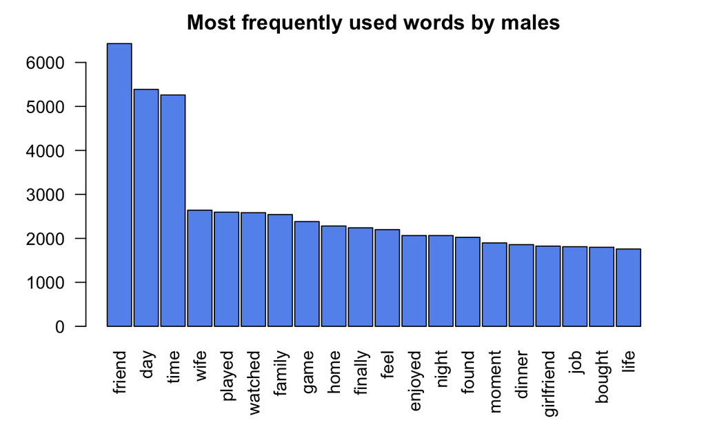

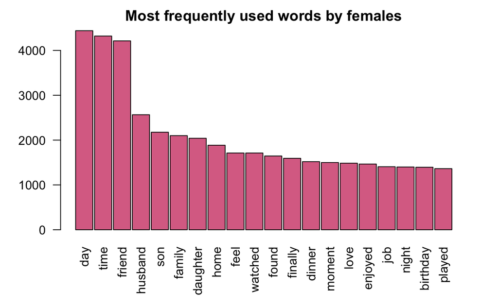

### Singles and Married Couples

Now, we look at the most used terms for singles and married couples. Again, the top 3 terms are ‘day’, ‘time’ and ‘friend’. However, for singles, the number of times ‘friend’ is used is much higher than any other term. In fact it is around triple that of the 4th term, ‘watched’. It is also interesting to note that ‘job’ ranks relatively highly for singles as well, implying that they derive happiness from ther careers due to perhaps a greater focus there. In contrast, for married couples, the difference between the top 3 terms and the rest is much smaller, and expectedly, family related terms rank highly.

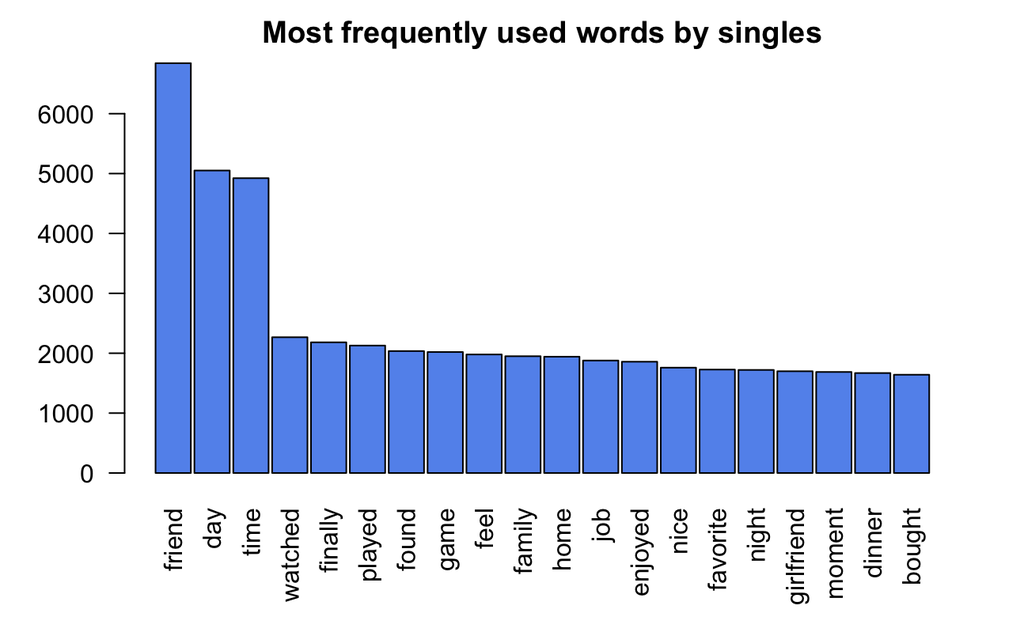

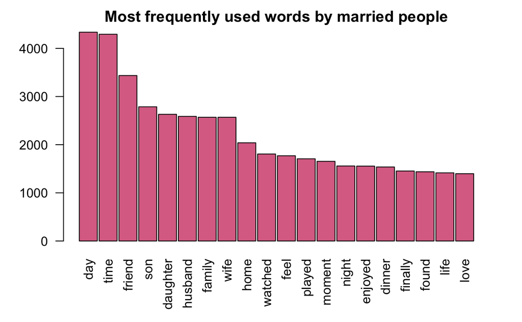

### Young and Old

Lastly, we look at the difference in terms used by the young (below median of 30) and old (above 30). The patterns we see here are largely similar to what we saw for the singles and married, which is not surprising given that there is a strong correlation between age and marital status. We would also expect the same correlation to be seen between age and parenthood. However, it is interesting that ‘birthday’ makes an appearance in the top 20 for young people, and we do know that young people like to celebrate their birthdays!

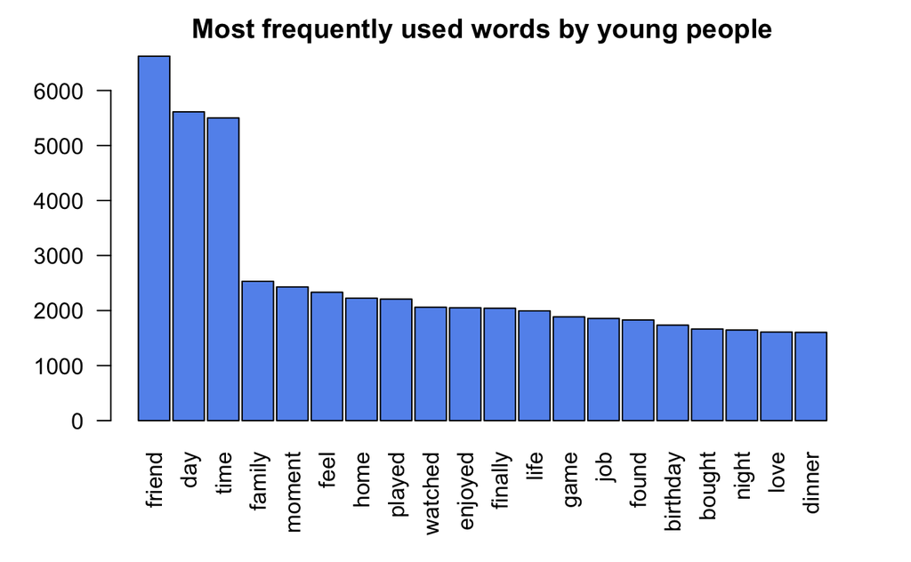

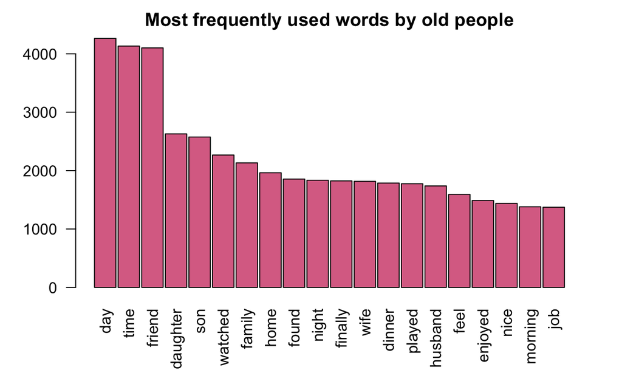

## Conclusion

We have drawn some interesting insights from our analysis of the HappyDB data. We see that there are differences in what makes a person happy based on their profile. We also see that the way that they write about their happiness is also affected by their background. Large companies and governments may find such information useful when they decide to market their products or craft policies for people, although they will definitely need more background research and to create a better predictive model for such purposes.

## References

Mohammad, S.M. (2018, August). *The NRC Valence, Arousal, and Dominance Lexicon*. Retrieved from https://saifmohammad.com/WebPages/nrc-vad.html.